# R Notebook

# 1. Phân tích ANOVA cho price theo 1 trong 3 dữ liệu định tính (cut,color,clarity) (dữ liệu: diamonds gói ggplot2)

```r
library(ggplot2)
```

```r
diamonds
```

| carat | cut | color | clarity | depth | table | price | x | y | z |
| --- | --- | --- | --- | --- | --- | --- | --- | --- | --- |
| 0.23 | Ideal | E | SI2 | 61.5 | 55.0 | 326 | 3.95 | 3.98 | 2.43 |
| 0.21 | Premium | E | SI1 | 59.8 | 61.0 | 326 | 3.89 | 3.84 | 2.31 |
| 0.23 | Good | E | VS1 | 56.9 | 65.0 | 327 | 4.05 | 4.07 | 2.31 |
| 0.29 | Premium | I | VS2 | 62.4 | 58.0 | 334 | 4.20 | 4.23 | 2.63 |
| 0.31 | Good | J | SI2 | 63.3 | 58.0 | 335 | 4.34 | 4.35 | 2.75 |
| 0.24 | Very Good | J | VVS2 | 62.8 | 57.0 | 336 | 3.94 | 3.96 | 2.48 |
| 0.24 | Very Good | I | VVS1 | 62.3 | 57.0 | 336 | 3.95 | 3.98 | 2.47 |
| 0.26 | Very Good | H | SI1 | 61.9 | 55.0 | 337 | 4.07 | 4.11 | 2.53 |
| 0.22 | Fair | E | VS2 | 65.1 | 61.0 | 337 | 3.87 | 3.78 | 2.49 |
| 0.23 | Very Good | H | VS1 | 59.4 | 61.0 | 338 | 4.00 | 4.05 | 2.39 |

[output cut: 990 more lines]

```r
data = diamonds[,c( "price", "cut", "color", "clarity")]
data
```

| price | cut | color | clarity |
| --- | --- | --- | --- |
| 326 | Ideal | E | SI2 |
| 326 | Premium | E | SI1 |
| 327 | Good | E | VS1 |
| 334 | Premium | I | VS2 |
| 335 | Good | J | SI2 |
| 336 | Very Good | J | VVS2 |
| 336 | Very Good | I | VVS1 |
| 337 | Very Good | H | SI1 |
| 337 | Fair | E | VS2 |
| 338 | Very Good | H | VS1 |

[output cut: 990 more lines]

```r
anv_model = aov(price ~ cut, data = data)
summary(anv_model)
```

```
               Df    Sum Sq   Mean Sq F value Pr(>F)
cut             4 1.104e+10 2.760e+09   175.7 <2e-16 ***
Residuals   53935 8.474e+11 1.571e+07
---
Signif. codes:  0 ‘***’ 0.001 ‘**’ 0.01 ‘*’ 0.05 ‘.’ 0.1 ‘ ’ 1
```

```r
anv_model2 = aov(price ~ color, data = data)
summary(anv_model2)
```

```
               Df    Sum Sq   Mean Sq F value Pr(>F)
color           6 2.685e+10 4.475e+09   290.2 <2e-16 ***
Residuals   53933 8.316e+11 1.542e+07
---
Signif. codes:  0 ‘***’ 0.001 ‘**’ 0.01 ‘*’ 0.05 ‘.’ 0.1 ‘ ’ 1
```

```r
anv_model3 = aov(price ~ cut * color, data = data)
summary(anv_model3)
```

```
               Df    Sum Sq   Mean Sq F value Pr(>F)
cut             4 1.104e+10 2.760e+09 181.405 <2e-16 ***
color           6 2.551e+10 4.251e+09 279.371 <2e-16 ***
cut:color      24 1.653e+09 6.889e+07   4.527  1e-12 ***
Residuals   53905 8.203e+11 1.522e+07
---
Signif. codes:  0 ‘***’ 0.001 ‘**’ 0.01 ‘*’ 0.05 ‘.’ 0.1 ‘ ’ 1
```

```r
data1 = read.csv("ferti.csv", header=TRUE)
data1
```

| drug | therapy | mood.gain |
| --- | --- | --- |
| placebo | no.therapy | 0.5 |
| placebo | no.therapy | 0.3 |
| placebo | no.therapy | 0.1 |
| anxifree | no.therapy | 0.6 |
| anxifree | no.therapy | 0.4 |
| anxifree | no.therapy | 0.2 |
| joyzepam | no.therapy | 1.4 |
| joyzepam | no.therapy | 1.7 |
| joyzepam | no.therapy | 1.3 |
| placebo | CBT | 0.6 |

[output cut: 8 more lines]

# 2. Drug

```r
anova2 = aov(mood.gain ~ drug * therapy, data=data1)
# anova2 = aov(mood.gain ~ drug + therapy + drug:therapy, data=data1)
summary(anova2)
```

[output not shown]

Kiểm tra phân phối chuẩn của phần dư

```r
shapiro.test(anova2$residuals)
```

```
    Shapiro-Wilk normality test

data:  anova2$residuals
W = 0.92882, p-value = 0.1851
```

H0: tuân theo pp chuẩn , H1: ko tuân theo pp chuẩn

p-value > 0.05 => Chấp nhận H0 => Tuân theo pp chuẩn

Kiểm tra phương sai đồng nhất

```r
library(car)
leveneTest(anova2)
```

```
Levene's Test for Homogeneity of Variance (center = median)
      Df F value Pr(>F)
group  5  0.0955 0.9912
      12
```

H0: Phương sai đồng nhất | H1: Phương sai ko đồng nhất

p-value > 0.05 => Phương sai có đồng nhất

```r
durbinWatsonTest(anova2)
```

```
 lag Autocorrelation D-W Statistic p-value
   1      -0.3605442      2.644558   0.888
 Alternative hypothesis: rho != 0
```

H0: Phần dư có độc lập | H1: Phần dư ko độc lập

p-value > 0.05 => Phần dư có độc lập

# 3. Phân bón

Kiểm định với mức ý nghĩa 1% (p-value < 0.01)

```r
yield = c(28, 21, 20, 18, 23,
          35, 42, 32, 25, 27,
          33, 38, 31, 42, 29)


fertilizer = c(rep("A", 5), rep("B", 5), rep("C", 5))

data2 = data.frame(fertilizer, yield)
data2
```

[output not shown]

```r
anova3 = aov(yield ~ fertilizer)
summary(anova3)
```

[output not shown]

H0: Phân bón ko có khác biệt | H1: Phân bón có khác biệt

# 4. Survival time

```r
time_point = c(rep("8h", 10), rep("16h", 9), rep("20h", 9), rep("24h", 10))
survival_time = c(3.33, 3.40, 3.43, 3.49, 3.63, 3.76, 3.85, 3.97, 4.40, 4.24,
                  3.29, 3.36, 3.40, 3.43, 3.68, 3.82, 3.87, 4.20, 4.49,
                  3.33, 3.36, 3.46, 3.52, 3.61, 3.71, 3.87, 4.09, 4.18,
                  3.37, 3.53, 3.76, 4.10, 4.13, 4.22, 4.28, 4.55, 4.69, 5)

data3 = data.frame(time_point, survival_time)
data3
```

| time_point | survival_time |
| --- | --- |
| 8h | 3.33 |
| 8h | 3.40 |
| 8h | 3.43 |
| 8h | 3.49 |
| 8h | 3.63 |
| 8h | 3.76 |
| 8h | 3.85 |
| 8h | 3.97 |
| 8h | 4.40 |
| 8h | 4.24 |

[output cut: 28 more lines]

```r
anova4 = aov(survival_time ~ time_point)
summary(anova4)
```

```
            Df Sum Sq Mean Sq F value Pr(>F)
time_point   3  1.467  0.4889   2.935 0.0472 *
Residuals   34  5.663  0.1666
---
Signif. codes:  0 ‘***’ 0.001 ‘**’ 0.01 ‘*’ 0.05 ‘.’ 0.1 ‘ ’ 1
```

H0: Ko có liên quan | H1: Có liên quan

p-value < 0.05 => Bác bỏ H0 => Có liên quan

Kiểm tra anova

```r
library(agricolae)
res = LSD.test(anova4, "time_point")
print(res)
```

```
$statistics
    MSerror Df     Mean       CV
  0.1665676 34 3.836842 10.63705

$parameters
        test p.ajusted     name.t ntr alpha
  Fisher-LSD      none time_point   4  0.05

$means
    survival_time       std  r        se      LCL      UCL  Min  Max   Q25   Q50    Q75
16h      3.726667 0.4120073  9 0.1360423 3.450195 4.003138 3.29 4.49 3.400 3.680 3.8700
20h      3.681111 0.3079953  9 0.1360423 3.404640 3.957582 3.33 4.18 3.460 3.610 3.8700
24h      4.163000 0.5101209 10 0.1290611 3.900716 4.425284 3.37 5.00 3.845 4.175 4.4825
8h       3.750000 0.3658172 10 0.1290611 3.487716 4.012284 3.33 4.40 3.445 3.695 3.9400

$comparison
NULL

$groups
    survival_time groups
24h      4.163000      a
8h       3.750000      b
16h      3.726667      b
20h      3.681111      b

attr(,"class")
[1] "group"
```

# 5. Tooth

```r
data4 = read.csv("tooth.csv")
data4
```

| x | y |
| --- | --- |
| 0.06 | 5.05 |
| 0.08 | 4.95 |
| 0.08 | 5.10 |
| 0.18 | 4.85 |
| 0.28 | 4.40 |
| 0.36 | 5.25 |
| 0.56 | 4.40 |
| 0.53 | 5.15 |
| 1.02 | 4.30 |
| 1.23 | 4.15 |

[output cut: 5 more lines]

```r
lm1 = lm(y~x, data=data4)
summary(lm1)
```

```
Call:
lm(formula = y ~ x, data = data4)

Residuals:
     Min       1Q   Median       3Q      Max
-0.48796 -0.13377 -0.04504  0.12690  0.49736

Coefficients:
            Estimate Std. Error t value Pr(>|t|)
(Intercept)   5.1515     0.1030   50.00  3.0e-16 ***
x            -0.9413     0.0771  -12.21  1.7e-08 ***
---
Signif. codes:  0 ‘***’ 0.001 ‘**’ 0.01 ‘*’ 0.05 ‘.’ 0.1 ‘ ’ 1

Residual standard error: 0.2622 on 13 degrees of freedom
Multiple R-squared:  0.9198,    Adjusted R-squared:  0.9136
F-statistic: 149.1 on 1 and 13 DF,  p-value: 1.698e-08
```

B0 = 5.1515

B1 = -0.9413

y = B0 + B1 * x

H0: B1 = 0 | H1: B1 != 0

p-value <0.05 => bác bỏ H0 => B1 !=0

# 6. 21/3

```r
data5 = read.csv("lmdata1.txt")
data5 = data5[c(2, 3)]
data5
```

| x | y |
| --- | --- |
| 1 | 4.365611 |
| 8 | 8.127354 |
| 10 | 9.096021 |
| 7 | 7.501730 |
| 9 | 8.078083 |
| 1 | 4.402429 |
| 10 | 8.940760 |
| 4 | 6.079711 |
| 2 | 5.093050 |
| 1 | 4.641315 |

[output cut: 10 more lines]

```r
anova5 = aov(y~x, data=data5)
summary(anova5)
```

```
            Df Sum Sq Mean Sq F value Pr(>F)
x            1  53.89   53.89    1571 <2e-16 ***
Residuals   18   0.62    0.03
---
Signif. codes:  0 ‘***’ 0.001 ‘**’ 0.01 ‘*’ 0.05 ‘.’ 0.1 ‘ ’ 1
```

```r
SSR = 53.89
SSE =  0.62
SST =  SSR + SSE

R_sq = SSR/SST
R_sq
```

```
[1] 0.9886259
```

```r
lm2 = lm(y~x, data=data5)
summary(lm2)
```

```
Call:
lm(formula = y ~ x, data = data5)

Residuals:
     Min       1Q   Median       3Q      Max
-0.40365 -0.11807  0.02581  0.12100  0.40166

Coefficients:
            Estimate Std. Error t value Pr(>|t|)
(Intercept)  4.01499    0.08144   49.30   <2e-16 ***
x            0.49630    0.01252   39.63   <2e-16 ***
---
Signif. codes:  0 ‘***’ 0.001 ‘**’ 0.01 ‘*’ 0.05 ‘.’ 0.1 ‘ ’ 1

Residual standard error: 0.1852 on 18 degrees of freedom
Multiple R-squared:  0.9887,    Adjusted R-squared:  0.988
F-statistic:  1571 on 1 and 18 DF,  p-value: < 2.2e-16
```

y = 0.49630*x + 4.01499

Tổng bình phương tp: SST

Tổng bình phương phần dư: SSE

phương sai phần dư: MSE = 0.03

Lấy ra x_0 là trung vị hoặc phân vị Q3 và đưa ra dự đoán với khoảng tin cậy 95%

```r
x_median = median(data5$x)
x_q3 = quantile(data5$x, 0.75)
x_q3
```

```
 75%
8.25
```

```r
predict(lm2, newdata=data.frame(x = x_median), interval="confidence",level=0.95)
```

```
       fit     lwr      upr
1 7.240969 7.15079 7.331147
```

```r
predict(lm2, newdata=data.frame(x = x_q3), interval="confidence",level=0.95)
```

```
       fit      lwr      upr
75% 8.1095 7.998002 8.220999
```

```r
shapiro.test(lm2$residuals)
```

```
    Shapiro-Wilk normality test

data:  lm2$residuals
W = 0.98106, p-value = 0.947
```

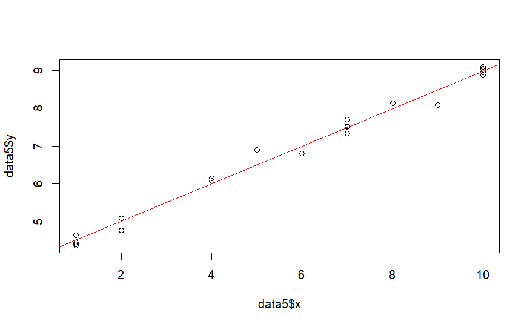

```r
plot(data5$x, data5$y)
abline(lm2, col="red")
```

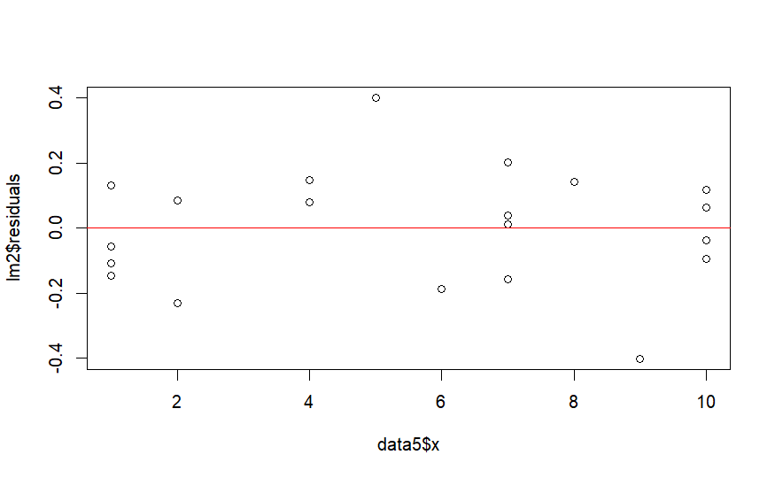

```r
plot(data5$x, lm2$residuals)
abline(h = 0, col = "red")
```

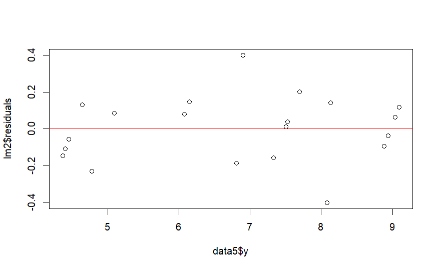

```r
plot(data5$y, lm2$residuals)
abline(h = 0, col = "red")
```